# Landsberg Model

Hao-Ran Wu ( haoranwu @ zju.edu.cn )

2022-09-16

In this section we are concerned about how to calculate ecosystem production based on Landsberg model.

## Code Example(s)

```r
# Ecosystem Production based on Landsberg Model
# *****************************************************************
#
# Calculate ecosystem production based on Michaelis-Menten (MM) Model (Landsberg,
# 1977).
#
# ********************************
# List of variables and units for this example
#
# 'PAR'           photosynthetically active radiation (PAR, μmol m-2 s-1)
# 'alpha'         slope of the change in photosynthesis rate with PAR
# 'Pm'            maximum photosynthetic capacity (μmol m-2 s-1)
# 'Icomp'         light compensation point (μmol m-2 s-1)
#
# Calculated variables in the program
# 'Pn'            photosynthesis rate (μmol m-2 s-1) given by Landsberg model
#
# ********************************
# Step 1: import package
require(bproce)

# Step 2: choose parameters
PAR   <- seq(0, 1000, 10)
alpha <- 0.008
Pm    <- 10
Icomp <- 200

# Step 3: run the model
Pn <- photo.landsberg(PAR, alpha = alpha, Pm = Pm, Icomp = Icomp)

# Step 4: present and visualize the result
print(data.frame(PAR = PAR, Pn = Pn), digits = 3)

plot(
  PAR, Pn, type="l",
  xlab = "Photosynthetically active radiation",
  ylab = "Photosynthesis rate",
  main = "Photosynthesis Rate Estimated by Landsberg Model"
)                       # plot photosynthesis rate versus PAR (MM model)
```

## Explanation

**Step1:** Load the package `bproce` through the `require()` function.

```r
require(bproce)
```

**Step2:** Choose model parameters.

- `PAR`: Photosynthetically active radiation ($PAR$, µmol m<sup>−2</sup> s<sup>−1</sup>). The provided example calculates photosynthesis rate ($P_n$, µmol m<sup>−2</sup> s<sup>−1</sup>) when $PAR$ changes from 0 to 1000 µmol m<sup>−2</sup> s<sup>−1</sup>.
- `alpha`: Slope of the change in photosynthesis rate with $PAR$. The provided example uses 0.008.
- `Pm`: Maximum photosynthetic capacity (µmol m<sup>−2</sup> s<sup>−1</sup>). The provided example uses 10 µmol m<sup>−2</sup> s<sup>−1</sup>.
- `Icomp`: Light compensation point (μmol m<sup>−2</sup> s<sup>−1</sup>) at which the photosynthesis rate is zero. The provided example uses 200.

```r
PAR   <- seq(0, 1000, 10)
alpha <- 0.008
Pm    <- 10
Icomp <- 200
```

where $P_m$ (µmol m<sup>−2</sup> s<sup>−1</sup>) is the maximum photosynthesis, *α* is the slope of the change in $P_n$ (µmol m<sup>−2</sup> s<sup>−1</sup>) with $PAR$ (i.e., a shape factor), and $I_{comp}$ (µmol m<sup>−2</sup> s<sup>−1</sup>) is the light compensation point at which $P_n$ is zero. The following example shows how to calculate $P_n$ using the Landsberg model:

```r
Pn <- photo.landsberg(PAR, alpha = alpha, Pm = Pm, Icomp = Icomp)

print(head(data.frame(PAR = PAR, Pn = Pn)), digits = 3)
```

```
  PAR    Pn
1   0 -39.5
2  10 -35.7
3  20 -32.2
4  30 -29.0
5  40 -26.0
6  50 -23.2
```

**Step4:** Visualize results. Create a line plot of $P_n$ against $PAR$ through the function `plot()`:

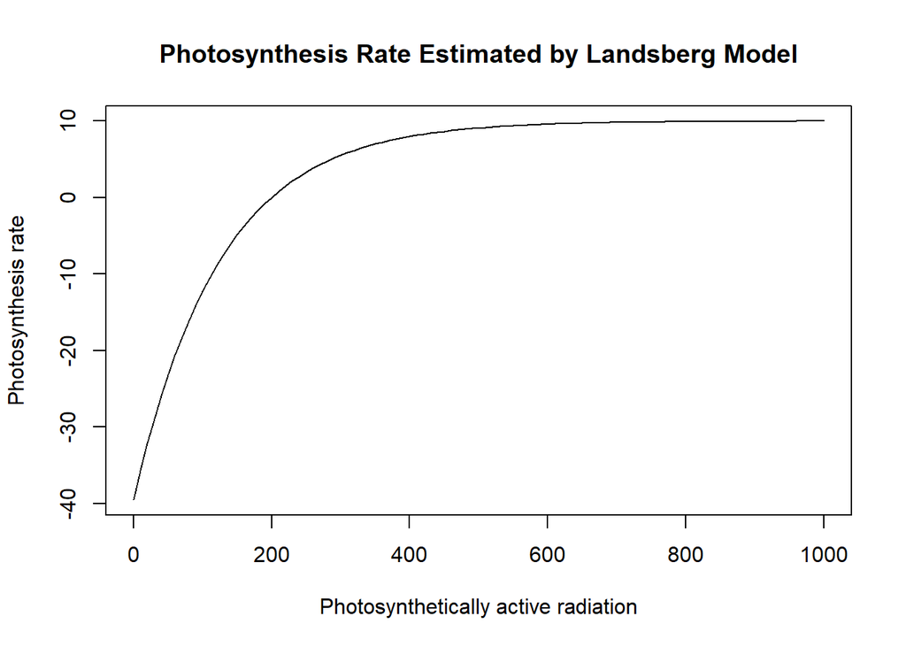

```r
plot(
  PAR, Pn, type="l",
  xlab = "Photosynthetically active radiation",
  ylab = "Photosynthesis rate",
  main = "Photosynthesis Rate Estimated by Landsberg Model"
)                       # plot photosynthesis rate versus PAR (MM model)
```

## Reference

Landsberg, J. J. (1977). Some useful equations for biological studies. Experimental Agriculture, 13(3), 273–286.